```python
import pandas as pd
import os

import numpy as np
import pandas as pd
import matplotlib.pyplot as plt
import matplotlib.image as mpimg

import datetime
import matplotlib.dates as mdates
```

# 1. Background

Neutrino detection: importance and methods

Related experiment: DUNE, neutrino oscillations, LAr chamber

Pixel detector technology to overcome challenges in detecting particle in large scale (kilotons) detector Previous version: Analog Q-pix, 16-channel bullseye, Argon gas chamber --> prototype for electronics test

This version: ASIC circuits, LAr, smaller scale of more realistic usage

- Impurities in Ar like Oxygen, Water leaking in from outside the chamber can make lifetime measurement inaccurate. When we did with analog Q-pix, we used PyBoltz to calculate the affect the impurities at different concentration has to the electron diffusion (the distribution of electrons cloud corelates to how much impurities are attached to the drifting electrons).
- For most efficient test, we want Liquid Argon to be pure all the time. Thus, we construct a purifier which filters out Oxygen and Water during regeneration process and provides us with pure liquid argon to refill the TPC.
- This experiment involves constructing the purity monitor (field cage) and a purifier (nipple with copper catalysts and molecular sieves) to experiment with the process. The main goal this summer is to get the system working and measure the purity of the output determined by electron lifetime measurement.
- Once the Q-Pix ASICs arrive, we can install it into the chamber with liquid argon and collect data.

# 2. Purity Monitor

Impurities in liquid Argon can ionize and lead to electrical discharge between the cathode and anode. The measurement of these discharges indicates the impurity level.

The purity monitor consists of a field cage generating uniform electric field. Electrons are generated at the cathode of the field cage via the photoelectric effect. A series of ultraviolet light pulses from xenon flash lamp is transmitted through a fiber optic cable to the photo-cathode positioned at the center of the field cage, stripping electrons from the material (we use a gold-coated plate). These electrons then drift upward through liquid Argon from cathode and are collected at anode. Wire meshes are placed on both ends of field cage to shield the cathode and anode from induced current.

[figure not shown]

## 2.1 Pressure Gauges:

We use rough and turbo pumps to put the system into vacuum and use pressure gauges to monitor the pressure drop as time preceeds. We use Convectron Gauge (CG) and Ion Gauge (IG).

CG works under high pressure down to 5e-2 Torr and IG only works from pressure less than 5e-2 Torr. As the pump the system down, we switch from CG to IG for an accurate low pressure readings.

IG can be damaged under high pressure, it is crucial to have the system switch the IG off when the pressure exceeds its 5e-2 Torr limit.

There are 2 ways to do this: 1) **Device's built-in logic:** Connect pin1,2 (GND) of the pressure gauge together, IG will be auto-on-off based on CG pressure. Switch to display summary to show both CG, IG. This way is safer as we have display and independent of the PC status.

2) **Python control through serial communcation:** The Hornet (pressure gauges) connection to RS485, TXD A+ (red pin9 (B+)), TXD B- (purple pin6 (A-)). Use the code [Here](https://github.com/IseeJ/TPCsim/blob/main/PressureGauge/ReadPressure.ipynb) to send command and read result in ASCII. Use the value to decide if IG should be on/off.

```python
#log pressure
#will use in GUI
"""
import Hornet #need to have Hornet.py
import time
from datetime import datetime as dt
import csv

now = dt.now()
filename = "pressure_log_"+str(now.strftime('%Y%m%d%H%M'))+".csv"
print("starting pressure log file: "+filename)

with open(filename, 'a') as csvfile:
    csvwriter = csv.writer(csvfile)
    csvwriter.writerow(['# DateTimestamp','CGPressure(Torr)', 'IGPressure(Torr)'])

    while True:
        CGpressure = Hornet.getConvectronP()
        IGpressure = Hornet.getIonP()
        now = dt.now()
        nowstr = now.strftime('%Y%m%dT%H%M%S')

        if str(Hornet.IG_stat())[11:-4] != "ON":
            IGpressure = 'NaN'

        print(nowstr, CGpressure, IGpressure)
        csvwriter.writerow([nowstr, CGpressure,IGpressure])

        # flush the file
        csvfile.flush()

    csvfile.close()
"""
```

## 2.2 Field Cage: Uniform Drift Field Simulation (FreeFEM)

plot to simulate Electric field in the field cage geometry (separation) and applied voltage at each ring, ensure it's uniform.

FreeFEM [code](https://github.com/IseeJ/TPCsim/tree/main/FreeFEM): contains Python script to generate the .edp file to solve the field from field cage geometry and applied voltage, saved result in .txt file for plotting in MatLab, and screenshots of the equipotential plot which shows our configurations provide the uniform drift field between cathode wire mesh and anode wire mesh.

[figure not shown]

## 2.3 Pre-Amplifier Calibration

20240617

Cremat has test capacitance 1 pF

$Q_{in}=C\Delta V_{in}$

Expect $V_{out}$ = (1.4 V/pC)(1 pC) = 1.4 V

Use the best fit to calibrate the signal (convert from measured voltage to the amount of charges recieved)

```
QCin=0.00061VCout + 0.01193
QAin=0.00064VAout + 0.00470
```

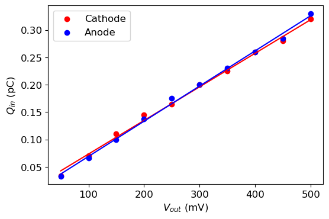

```python
plt.figure(dpi=100)
plt.rcParams['font.size'] = 12
df = pd.read_csv("PurityMonitor/calib.csv")
CVout, CVin = np.array(df["CVout"]),np.array(df["CVin"])
AVout, AVin = np.array(df["AVout"]),np.array(df["AVin"])

#plt.scatter(CVout,CVin, label="Cathode", color = "r")
#plt.scatter(AVout,AVin, label="Anode", color="b")

plt.xlabel(r"$V_{out}$ (mV)")
plt.ylabel(r"$Q_{in}$ (pC)")

def get_slope(x, y):
    coefficients = np.polyfit(x, y, 1)
    slope = coefficients[0]
    intercept = coefficients[1]
    return slope, intercept

CQin = (1)*(CVin*1e-3) #C=1pF
AQin = (1)*(AVin*1e-3)

Cslope, Cint = get_slope(CVout, CQin)
Aslope, Aint = get_slope(AVout, AQin)

print(f'QCin={Cslope:.5f}VCout + {Cint:.5f}')
print(f'QAin={Aslope:.5f}VAout + {Aint:.5f}')

plt.scatter(CVout,CQin, label="Cathode", color = "r")
plt.scatter(AVout,AQin, label="Anode", color="b")


plt.plot(CVout, Cslope * CVout + Cint, color='r')
plt.plot(AVout, Aslope * AVout + Aint, color='b')

plt.legend()
plt.show()
```

## 2.5 Electron lifetime calculation

20240612

Impurities in the medium attaches to the drifting electron, causing $Q_A$, the charge measured at anode to be smaller than $Q_C$ at cathode. The ratio $Q_A/Q_C$ is used to calculate electron lifetime.

Drift electron attenuation in a purity monitor as a function of electron lifetime: $\tau = -\frac{t_{\text{drift}}}{\ln(Q_A / Q_C)}$

using the calibration to convert voltage (mV) to charge (pC),

$Q_Cin=0.61V_Cout + 11.93$

$Q_Ain=0.64V_Aout + 4.70$

```python
#%matplotlib notebook
%matplotlib inline

def get_data(file_path):
    plt.rcParams['font.size'] = 16
    df = pd.read_csv(file_path,skiprows=14)
    time = np.array(df["TIME"])
    CH2 = np.array(df["CH2"])
    CH3 = np.array(df["CH3"])
    return time,CH2,CH3

def calc(CV1,CV2,AV1,AV2,t1,t2,t3,t4):
    delt = t3-t1
    VC = np.abs(CV2-CV1)
    VA = np.abs(AV2-AV1)
    #convert to Q with linear fit from calibration
    QC = round(VC*0.00061+0.01193,5)
    QA = round(VA*0.00064+0.00470,5)
    ratio = round(QC/QA,2)
    tau = round(delt/(np.log(ratio)),1)
    n = 1/((4e12)*(tau*1e-6))
    print(f"tdrift = {round(delt,1)} μs, QA = {QA} pC, QC = {QC} pC, QC/QA = {ratio}, 𝜏 = {tau} μs, n = {round(n*1e9,2)} ppb")
```

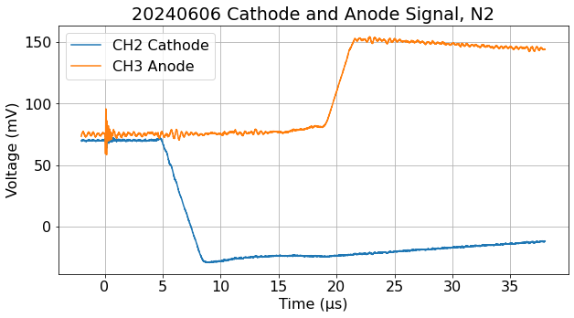

```
First Data 20240606:
tdrift = 13.9 μs, QA = 0.05084 pC, QC = 0.07311 pC, QC/QA = 1.44, 𝜏 = 38.2 μs, n = 6.54 ppb
```

```python
#20240606
plt.figure(figsize=(10,5))
time,CH2,CH3 = get_data("/Users/warisajaidee/Desktop/Battatlab/rawdata/tek0009ALL.csv")
plt.title("20240606 Cathode and Anode Signal, N2")
plt.plot(time*1e6,CH2*1e3, label="CH2 Cathode")
plt.plot(time*1e6,CH3*1e3, label="CH3 Anode")
plt.xlabel(u"Time (\u03bcs)")
plt.ylabel("Voltage (mV)")
plt.grid(True)
plt.legend()
plt.show()

print("First Data 20240606:")
calc(CV1 = -28.8, CV2 =71.5 ,AV1 = 80.5,AV2 = 152.6, t1=4.82, t2=8.45, t3=18.75, t4=21.61)
```

```
QCin=0.00061VCout + 0.01193
QAin=0.00064VAout + 0.00470
```

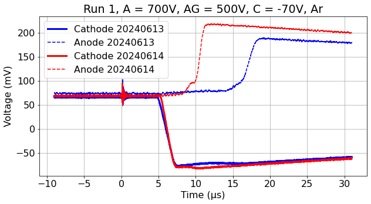

```
Run1 20240613
tdrift = 9.3 μs, QA = 0.07491 pC, QC = 0.09989 pC, QC/QA = 1.33, 𝜏 = 32.6 μs, n = 7.67 ppb

Run1 20240614
tdrift = 3.4 μs, QA = 0.09488 pC, QC = 0.10282 pC, QC/QA = 1.08, 𝜏 = 43.9 μs, n = 5.69 ppb
```

```python
#RUN1
time1, CH2_1, CH3_1= get_data("PurityMonitor/20240613_run1.csv")
time2, CH2_2, CH3_2= get_data("PurityMonitor/20240614_run1.csv")
#calibrated charge
print(f'QCin={Cslope:.5f}VCout + {Cint:.5f}')
print(f'QAin={Aslope:.5f}VAout + {Aint:.5f}')


plt.figure(figsize=(10,5))
plt.plot((time1+0.01e-5)*1e6,(CH2_1-0.01)*1000, label="Cathode 20240613", color = "blue", linewidth=3)
plt.plot((time1+0.01e-5)*1e6,(CH3_1+0.01)*1000, label="Anode 20240613", color = "blue", linestyle = "dashed")
plt.plot(time2*1e6,CH2_2*1000, label="Cathode 20240614", color = "r", linewidth=3)
plt.plot(time2*1e6,CH3_2*1000, label="Anode 20240614", color = "r", linestyle = "dashed")

plt.xlabel(u"Time (\u03bcs)")
plt.ylabel("Voltage (mV)")
plt.title("Run 1, A = 700V, AG = 500V, C = -70V, Ar")
plt.grid(True)
plt.legend()
#plt.savefig('Run1.jpg',bbox_inches='tight')
plt.show()


print("Run1 20240613")
calc(CV1 = -77.4, CV2 = 66.8,AV1 = 189.3, AV2 = 79.6, t1=4.79, t2=7.42, t3=14.1, t4=18.52)
print("\nRun1 20240614")
calc(CV1 = -79.8, CV2 = 69.2,AV1 = 77.3,AV2 = 218.2, t1=5.05, t2=7.29, t3=8.43, t4=11.5)
```

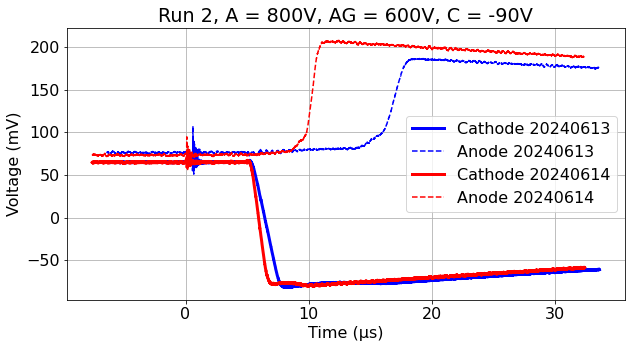

```python
time1, CH2_1, CH3_1= get_data("PurityMonitor/20240613_run2.csv") #4
time2, CH2_2, CH3_2  = get_data("PurityMonitor/20240614_run2.csv") #11


plt.figure(figsize=(10,5))
plt.plot((time1)*1e6+0.5,(CH2_1-0.006)*1000, label="Cathode 20240613", color = "blue", linewidth=3)
plt.plot((time1)*1e6+0.5,(CH3_1+0.01)*1000, label="Anode 20240613", color = "blue", linestyle = "dashed")

plt.plot(time2*1e6,CH2_2*1000, label="Cathode 20240614", color = "r", linewidth=3)
plt.plot(time2*1e6,CH3_2*1000, label="Anode 20240614", color = "r", linestyle = "dashed")\


#plt.axhline(y=0.06, color='b', label=f"0.06V", )



plt.xlabel(u"Time (\u03bcs)")
plt.ylabel("Voltage (mV)")
plt.title("Run 2, A = 800V, AG = 600V, C = -90V")



plt.grid(True)
plt.legend()
#plt.savefig('Run2.jpg',bbox_inches='tight')
plt.show()
```

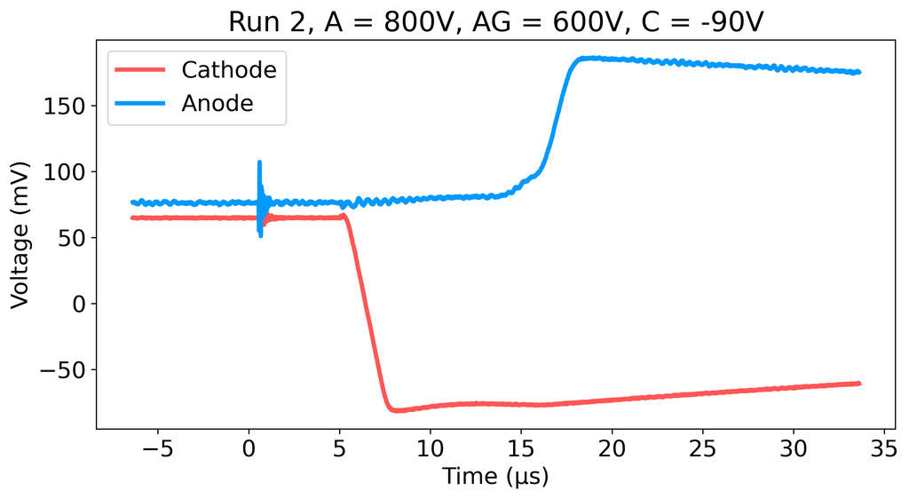

```python
time1, CH2_1, CH3_1= get_data("PurityMonitor/20240613_run2.csv") #4
time2, CH2_2, CH3_2  = get_data("PurityMonitor/20240614_run2.csv") #11


plt.figure(figsize=(10,5), dpi=300)
plt.plot((time1)*1e6+0.5,(CH2_1-0.006)*1000, label="Cathode", color = [235/235,80/235,79/235], linewidth=3)
plt.plot((time1)*1e6+0.5,(CH3_1+0.01)*1000, label="Anode", color = [0/235,141/235,235/235], linewidth = 3)

#plt.plot(time2*1e6,CH2_2*1000, label="Cathode 20240614", color = "r", linewidth=3)
#plt.plot(time2*1e6,CH3_2*1000, label="Anode 20240614", color = "r", linestyle = "dashed")\


#plt.axhline(y=0.06, color='b', label=f"0.06V", )



plt.xlabel(u"Time (\u03bcs)")
plt.ylabel("Voltage (mV)")
plt.title("Run 2, A = 800V, AG = 600V, C = -90V")



#plt.grid(True)
plt.legend()
#plt.savefig('Run2.jpg',bbox_inches='tight')
plt.show()
```

20240620: We switched out power supply for anode, anode grid, did another electron lifetime measurement using the Argon gas remained inside the purity monitor. The lifetime got worse as expected, by the factor of 2.

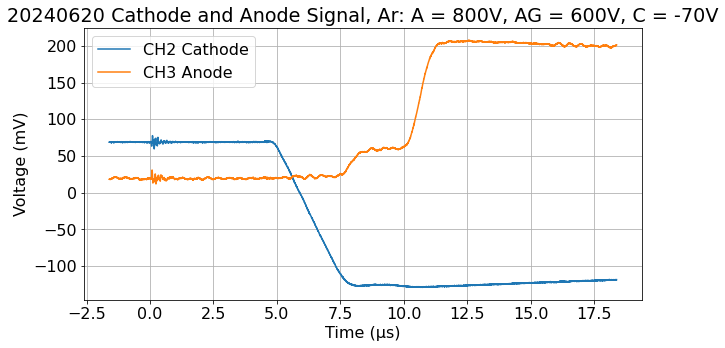

```
20240620:
tdrift = 5.2 μs, QA = 0.09545 pC, QC = 0.1318 pC, QC/QA = 1.38, 𝜏 = 16.0 μs, n = 15.62 ppb
```

```python
plt.figure(figsize=(10,5))
time,CH2,CH3 = get_data("/Users/warisajaidee/Desktop/Battatlab/PurityMonitor/20240620.csv")
plt.title("20240620 Cathode and Anode Signal, Ar: A = 800V, AG = 600V, C = -70V")
plt.plot(time*1e6,CH2*1e3, label="CH2 Cathode")
plt.plot(time*1e6,CH3*1e3, label="CH3 Anode")
plt.xlabel(u"Time (\u03bcs)")
plt.ylabel("Voltage (mV)")
plt.grid(True)
plt.legend()
plt.show()

print("20240620:")
calc(CV1 = -125, CV2 =71.5 ,AV1 = 62.4,AV2 = 204.2, t1=4.75, t2=7.86, t3=9.9, t4=11.44)
```

## 2.6 Impurities determination

$\tau_A = \frac{1}{k_An}$

where $k_A$ is the attachment rate constant (cross-section) and n is the impurity concentration in ppm

```python
n = 1/((4e12)*(16e-6))
print(n)
#15 ppb

#UHP Ar --> O2 1 ppm (e-6)
#lifetime is worse by 2x
#need ka for gas
#16us --> 10 ppb = 1000ppm
```

```
1.5625e-08
```

# 3. Purifier & LAr Regeneration

Two main impurities in the LAr chamber are water and oxygen. High-purity liquid argon can be produced during cryogenic separation of air. We input liquid argon into the purifier which heats it up as it flows through the filters, this effectively separates the components by their boiling points, leaving pure argon at the output.

## 3.1 Regeneration process & Setup

Liquid Argon Input $\rightarrow$ 0.3 kg molecular sieves in the bottom nipple for water removal $\rightarrow$ 1.3 kg copper catalysts (GetterMax 133 tablets) in the upper nipple for oxygen removal $\rightarrow$ Pure Liquid Argon Output

In the regeneration process of liquid argon, molecular sieves absorb smaller molecules (water, other impurities) into its pores while allowing larger molecules (liquid argon) to pass through. while copper catalysts are used to reduce oxygen. The copper oxide in the catalyst reacts with hydrogen to form solid copper and water vapor, effectively removing oxygen from the system. This process ensures the high purity of regenerated liquid argon for our use in electronic testing of Q-pix pixel detector.

$CuO+H_2 \rightarrow Cu+H_2O$

We use a copper based catalyst, GetterMax133 tablets which are activated during the regeneration process for oxygen reduction. This requires a gas mixture of 1-2% $H_2$. Hydrogen gas acts as a reducing agent and removes $O_2$. The copper oxide heats up and reacts with the hydrogen molecules, producing solid copper metal and water vapor.

## 3.2 Temperature Display

Regen test 1 20240614

2 heat tapes, wrapped around lower (H1) and upper (H2) nipples.

Eventually, we want to have all thermocouples connected to datalogger that provides API communication for temperature display on PC and the display on the device.

7 thermocouples are installed to keep track of temperature, inside and outside the purifier. 4 is connected to PerfectPrime data logger, and 3 is connected to LabJack T7. The PerfectPrime 4-channel data logger and the new Omega's 8-channel datalogger have a built-in display but don't have the API communication.

### PerfectPrime data

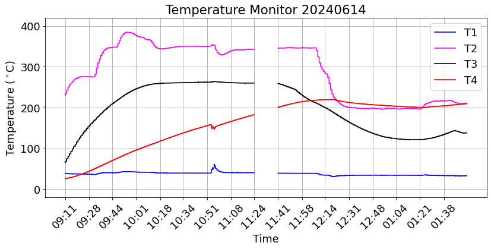

```python
import numpy as np
import pandas as pd
import matplotlib.pyplot as plt
import matplotlib.dates as mdates
import datetime


#Deal with data gap
def getdata_csv(filename):
    headers =["Date","Time","T1","T2","T3","T4"]
    df = pd.read_csv(filename, names = headers)
    return df
df1 = getdata_csv("Tempread/20240614_regen1.CSV")
df2 = getdata_csv("Tempread/20240614_regen2.CSV")

#print(df1['Time'].iloc[-1]) #last of df1
#print(df2['Time'].iloc[0]) #first of df2

start_time = datetime.time(11, 24, 56) #last of df1
end_time = datetime.time(11, 41, 29) #first of df2
total_seconds = (datetime.datetime.combine(datetime.date(2024,6,14), end_time) - datetime.datetime.combine(datetime.date(2024,6,14), start_time)).total_seconds()
times = []
current_time = datetime.datetime.combine(datetime.date.today(), start_time)
interval = datetime.timedelta(seconds=2)

while current_time.time() <= end_time:
    formatted_time = current_time.strftime("%I:%M:%S %p")
    times.append(formatted_time)
    current_time += interval

df_gap = pd.DataFrame(times, columns=['Time'])
df_gap["Date"] = "6/14/2024"
df_gap["T1"], df_gap["T2"], df_gap["T3"], df_gap["T4"] = "NaN","NaN","NaN","NaN" #fill witn NaN

combined_df = pd.concat([df1, df_gap, df2]).reset_index(drop=True)
combined_df.to_csv('combined_data.csv', index=False)

#Plotting combined data
plt.rcParams['font.size'] = 16
df = pd.read_csv("combined_data.csv")
time = np.array(pd.to_datetime(df['Time'], format=('%I:%M:%S %p')).dt.strftime('%I:%M'))
plt.figure(figsize=(12, 5), dpi=80)

plt.plot(time, np.array(df['T1']), color = "blue", label="T1")
plt.plot(time, np.array(df['T2']), color = "magenta", label="T2")
plt.plot(time, np.array(df['T3']), color = "black", label="T3")
plt.plot(time, np.array(df['T4']), color = "red", label="T4")

plt.xlabel("Time")
plt.title("Temperature Monitor 20240614")
plt.ylabel(f"Temperature ($^\circ$C)")
plt.fill_between([time[3999],time[4000]], 0, 400, alpha=0.5, color="gray")
plt.xticks(time[::500], rotation=45)
plt.legend()
plt.grid(True)
plt.show()
```

### LabJack T7 data

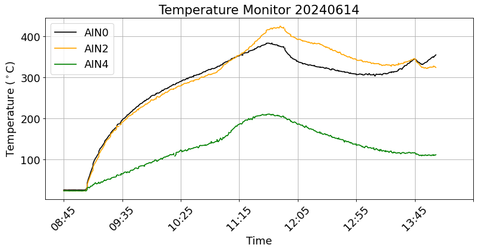

```python
def get_datafromdat(filename):
    with open(filename, 'r') as f:
        Timestamp, Hours, AIN0, AIN2, AIN4 = [],[],[],[],[]
        for line in f:
            columns = line.split()
            unixtime = columns[0]
            Timestamp.append(columns[0])

            Hours.append(datetime.datetime.fromtimestamp(float(unixtime)).strftime('%H:%M'))
            """
            formattime = datetime.datetime.fromtimestamp(float(unixtime))
            time_str = formattime.strftime('%H:%M:%S')
            Hours.append(time_str)
            """
            AIN0.append(round(float(columns[1]),2))
            AIN2.append(round(float(columns[3]),2))
            AIN4.append(round(float(columns[5]),2))
    return Timestamp, Hours, AIN0, AIN2, AIN4

def plot_T7data(filename, labels=False):
    filepath = "TempRead/"+filename
    plt.rcParams['font.size'] = 16
    Timestamp, Hours, AIN0, AIN2, AIN4 = get_datafromdat(filepath)
    colors = ["black","orange","green"]

    evr = 100
    if labels:
        plt.plot(Hours[::evr],AIN0[::evr], label = "AIN0", color = colors[0])
        plt.plot(Hours[::evr],AIN2[::evr], label = "AIN2", color = colors[1])
        plt.plot(Hours[::evr],AIN4[::evr], label = "AIN4", color = colors[2])
    else:
        plt.plot(Hours[::evr],AIN0[::evr], color = colors[0])
        plt.plot(Hours[::evr],AIN2[::evr], color = colors[1])
        plt.plot(Hours[::evr],AIN4[::evr], color = colors[2])

plt.figure(figsize=(10, 5), dpi=80)
plot_T7data("data_21.dat", labels=["AIN0", "AIN2", "AIN4"])
plot_T7data("data_22.dat")
plot_T7data("data_23.dat")
plot_T7data("data_24.dat")
plot_T7data("data_25.dat")
plot_T7data("data_26.dat")
plot_T7data("data_27.dat")

tick_positions = np.arange(0, 400, 50)
plt.xticks(tick_positions, rotation=45)

plt.legend()
plt.grid(True)
plt.tight_layout()

plt.xlabel("Time")
plt.title("Temperature Monitor 20240614")
plt.ylabel(f"Temperature ($^\circ$C)")

plt.show()
```

### GUI design for Temperature display

20240613

LabJack T7 appends temperature readings to a .dat file simultaneously as the datalogger update temperature plot. Python code is used to grab latest data logged on the file and display on top of the experimental setup diagram to show temperature at different location thermocouples are installed. The display helps monitor the flow of gas/liquid inside the purifier during regeneration process and help us assess the heat loss at each state.

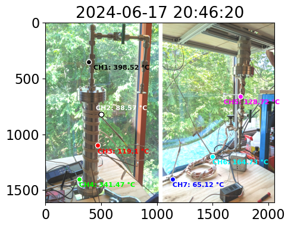

```
stop
```

```python
#draft
import matplotlib.pyplot as plt
import matplotlib.image as mpimg
import csv
import time
from IPython.display import clear_output

img_path = 'Tempread/Diagram.png'
img = mpimg.imread(img_path)

def lastest_data(csv_file):
    with open(csv_file, 'r') as file:
        data = csv.reader(file)
        latest_entry = None
        for row in data:
            latest_entry = row
        return latest_entry

def update_image(image_path, CH1, CH2,CH3,CH4,CH5,CH6,CH7, timestamp):
    img = mpimg.imread(image_path)
    plt.figure(dpi=100)
    plt.imshow(img)

    plt.text(430, 420, f"CH1: {CH1} °C", fontsize=8, color='black', fontweight='bold',)
    plt.scatter(390,350,color='black',edgecolors='white')

    plt.text(450, 780, f"CH2: {CH2} °C", fontsize=8, color='white', fontweight='bold')
    plt.scatter(500,820,color='white',edgecolors='black')

    plt.text(470, 1170, f"CH3: {CH3} °C", fontsize=8, color='red', fontweight='bold')
    plt.scatter(470,1100,color='red',edgecolors='white')

    plt.text(300,1470, f"CH4: {CH4} °C", fontsize=8, color='lime', fontweight='bold')
    plt.scatter(300,1400,color='lime',edgecolors='white')

    plt.text(1600,730, f"CH5: {CH5} °C", fontsize=8, color='magenta', fontweight='bold')
    plt.scatter(1750,660,color='magenta',edgecolors='white')

    plt.text(1500,1270, f"CH6: {CH6} °C", fontsize=8, color='cyan', fontweight='bold')
    plt.scatter(1500,1200,color='cyan',edgecolors='white')

    plt.text(1140,1470, f"CH7: {CH7} °C", fontsize=8, color='blue', fontweight='bold')
    plt.scatter(1140,1400,color='blue',edgecolors='white')


    plt.title(timestamp)
    plt.show()

csv_file = 'Tempread/realtimedata_test2.csv'

latest_entry = lastest_data(csv_file)
if latest_entry:
    timestamp = str(latest_entry[1])
    CH1 = float(latest_entry[2])
    CH2 = float(latest_entry[3])
    CH3 = float(latest_entry[4])
    CH4 = float(latest_entry[5])
    CH5 = float(latest_entry[6])
    CH6 = float(latest_entry[7])
    CH7 = float(latest_entry[8])

    update_image(img_path, CH1, CH2, CH3,CH4,CH5,CH6,CH7, timestamp)


if __name__ == "__main__":
    try:
        while True:
            time.sleep(1)
            new_entry = lastest_data(csv_file)
            if new_entry != latest_entry:
                latest_entry = new_entry
                timestamp = str(latest_entry[0])
                CH1 = float(latest_entry[1])
                CH2 = float(latest_entry[2])
                CH3 = float(latest_entry[3])
                CH4 = float(latest_entry[4])
                CH5 = float(latest_entry[5])
                CH6 = float(latest_entry[6])
                CH7 = float(latest_entry[7])

                clear_output(wait=True)
                update_image(img_path, CH1, CH2,CH3,CH4,CH5,CH6,CH7, timestamp)

    except KeyboardInterrupt:
            print("stop")
```

### Making Temperature Display GUI with PyQt5

20240618

```python
#real GUI
import sys
import csv
import time
import numpy as np

from PyQt5 import QtWidgets, QtCore

import matplotlib
matplotlib.use('Qt5Agg')
from matplotlib.backends.backend_qt5agg import FigureCanvasQTAgg as FigureCanvas
from matplotlib.figure import Figure
from IPython.display import clear_output

import matplotlib.image as mpimg

class MplCanvas(FigureCanvas):
    def __init__(self, parent=None, width=5, height=4, dpi=100):
        fig = Figure(figsize=(width, height), dpi=dpi)
        self.axes = fig.add_subplot(111)
        super(MplCanvas, self).__init__(fig)

        self.csv_file = 'Tempread/realtimedata_test2.csv'
        self.latest_entry = None

        self.timer = QtCore.QTimer(self)
        self.timer.timeout.connect(self.update_image)
        self.timer.start(1000)

    def latest_datacsv(self, csv_file):
        with open(csv_file, 'r') as file:
            data = csv.reader(file)
            for row in data:
                latest_entry = row
            return latest_entry

    def latest_datadat(self, dat_file):
        with open(dat_file, 'r') as file:
            lines = file.readlines()
            last_line = lines[-1].strip()
            latest_entry = last_line.split()
            return latest_entry

    def update_image(self):

        self.axes.cla() # Clear the canvas.

        #old code
        new_entry = self.latest_datacsv(self.csv_file)
        if new_entry and new_entry != self.latest_entry:
            self.latest_entry = new_entry
            timestamp = str(new_entry[1])
            CH1 = round(float(new_entry[2]),2)
            CH2 = round(float(new_entry[3]),2)
            CH3 = round(float(new_entry[4]),2)
            CH4 = round(float(new_entry[5]),2)
            CH5 = round(float(new_entry[6]),2)
            CH6 = round(float(new_entry[7]),2)
            CH7 = round(float(new_entry[8]),2)

            #self.axes.scatter([1, 2, 3, 4, 5, 6, 7], [CH1, CH2, CH3, CH4, CH5, CH6, CH7]) #test

            #plot image
            img = mpimg.imread('Tempread/Diagram.png')
            self.axes.imshow(img)
            self.fontsize = 10
            #scatter plot on top of img
            self.axes.text(430, 420, f"CH1: {CH1} °C", fontsize=self.fontsize, color='black', fontweight='bold')
            self.axes.scatter(390, 350, color='black', edgecolors='white')

            self.axes.text(450, 780, f"CH2: {CH2} °C", fontsize=self.fontsize, color='white', fontweight='bold')
            self.axes.scatter(500, 820, color='white', edgecolors='black')

            self.axes.text(470, 1170, f"CH3: {CH3} °C", fontsize=self.fontsize, color='red', fontweight='bold')
            self.axes.scatter(470, 1100, color='red', edgecolors='white')

            self.axes.text(300, 1470, f"CH4: {CH4} °C", fontsize=self.fontsize, color='lime', fontweight='bold')
            self.axes.scatter(300, 1400, color='lime', edgecolors='white')

            self.axes.text(1600, 730, f"CH5: {CH5} °C", fontsize=self.fontsize, color='magenta', fontweight='bold')
            self.axes.scatter(1750, 660, color='magenta', edgecolors='white')

            self.axes.text(1500, 1270, f"CH6: {CH6} °C", fontsize=self.fontsize, color='cyan', fontweight='bold')
            self.axes.scatter(1500, 1200, color='cyan', edgecolors='white')

            self.axes.text(1140, 1470, f"CH7: {CH7} °C", fontsize=self.fontsize, color='blue', fontweight='bold')
            self.axes.scatter(1140, 1400, color='blue', edgecolors='white')


            self.axes.set_title(timestamp)
            self.axes.axis('off')
            # Trigger the canvas to update and redraw.
            self.draw()



class MainWindow(QtWidgets.QMainWindow):
    def __init__(self, *args, **kwargs):
        super(MainWindow, self).__init__(*args, **kwargs)
        self.canvas = MplCanvas(self, width=5, height=4, dpi=100)
        self.setCentralWidget(self.canvas)

        self.show()


app = QtWidgets.QApplication(sys.argv)
w = MainWindow()
app.exec_()
```

```
0
```

### Serial Comm with Omega 8-channel

20240618

We want a temperature monitor device that provides both display and python communication. The Omega's 8 Channel Handheld Thermocouple Thermometer/Data Logger provides display with a software. The serial trace shows the hexadecimal written and read from the device. Through some decoding, we can extract the bits corresponding to the temperature read for thermocouple connected to each channel. This way we can have realtime display and data acquisation system for our GUI!

- From serial trace in OM-HL-EH-TC, the serial communication shows

Write: 01 16 7B 28 48 4C 45 48 54 43 34 30 39 35 67 71 29 7D 7E 04

Read: 01 16 7b 28 48 4c 45 48 54 43 34 30 39 35 68 71 **e3 00 2b 01 00 00 00 00 00 00 00 00 00 00 00 00** c6 29 7d 7e 04

where the first 16 bits and last 4 bits are the same in all T readings. And we suspect that the middle 16 bits represents temperature readings for the 8 channels (2 bits or 4 digits per channel).

- Temperature is recorded in 4 digits Hexadecimal number read backward (Little endian system: stores the least-significant byte at the smallest address) For example, the conversion between the reading in channel T2 would be, 2b 01 --> 012b --> 299 --> 29.9 degrees Celsius

```python
print("T1: ", int("00e3",16))
print("T2: ", int("012b",16))
```

```
T1:  227
T2:  299
```

- To ensure this logic makes sense, double check with the device's spec where

T range = -200～1800℃ --> report in -2000-180000 *10℃

18000 = 4650

--> 2 hex bits are enough to display the whole range of temp

```python
print(hex(-18)) #-7d0 *negative temperature is actually represented using Two's complement

print(hex(18000)) #4650
```

```
-0x12
0x4650
```

```python
#Ver 1

import serial
import time
from datetime import datetime as dt
serial_port = '/dev/cu.usbserial-110'
baud_rate = 38400
hex_data = [0x01, 0x16, 0x7B, 0x28, 0x48, 0x4C, 0x45, 0x48, 0x54, 0x43, 0x34, 0x30, 0x39, 0x35, 0x67, 0x71, 0x29, 0x7D, 0x7E, 0x04]
byte_data = bytearray(hex_data)

ser = serial.Serial(serial_port, baud_rate, timeout=1)


def readtemp(ser, byte_data):
    ser.write(byte_data)
    print(f"Write: {byte_data.hex()}")
    time.sleep(0.1)
    print(ser.in_waiting)
    if ser.in_waiting == 37:
        response = ser.readline()
        if response:
            response_hex = response.hex()
            print(f"Read:  {response_hex}")

            T1 = int(response_hex[34:36] + response_hex[32:34], 16) / 10  # T1
            T2 = int(response_hex[38:40] + response_hex[36:38], 16) / 10  # T2
            T3 = int(response_hex[42:44] + response_hex[40:42], 16) / 10  # T3
            T4 = int(response_hex[46:48] + response_hex[44:46], 16) / 10  # T4

            T5 = int(response_hex[50:52] + response_hex[48:50], 16) / 10  # T5
            T6 = int(response_hex[54:56] + response_hex[52:54], 16) / 10  # T6
            T7 = int(response_hex[58:60] + response_hex[56:58], 16) / 10  # T7
            T8 = int(response_hex[62:64] + response_hex[60:62], 16) / 10  # T8

            print(f"T1: {T1}, T2: {T2}, T3: {T3}, T4: {T4}\nT5: {T5}, T6: {T6}, T7: {T7}, T8: {T8}\n")

start_time = time.time()
while (time.time() - start_time) <= 5:
    try:
        now = dt.now()
        nowstr = now.strftime('%Y%m%dT%H%M%S')
        print(nowstr)
        readtemp(ser, byte_data)

    except KeyboardInterrupt:

        ser.close()
        exit()
ser.close()
```

```
20240626T140747
Write: 01167b28484c45485443343039356771297d7e04
37
Read:  01167b28484c45485443343039356871e000dd00db00dc00e000df00de00dd0009297d7e04
T1: 22.4, T2: 22.1, T3: 21.9, T4: 22.0
T5: 22.4, T6: 22.3, T7: 22.2, T8: 22.1

20240626T140748
Write: 01167b28484c45485443343039356771297d7e04
37
Read:  01167b28484c45485443343039356871e000dd00db00dc00e000df00de00dd0009297d7e04
T1: 22.4, T2: 22.1, T3: 21.9, T4: 22.0
T5: 22.4, T6: 22.3, T7: 22.2, T8: 22.1

20240626T140749
Write: 01167b28484c45485443343039356771297d7e04
37
Read:  01167b28484c45485443343039356871e000dd00db00dc00e000df00de00dd0009297d7e04
T1: 22.4, T2: 22.1, T3: 21.9, T4: 22.0
T5: 22.4, T6: 22.3, T7: 22.2, T8: 22.1

20240626T140750
Write: 01167b28484c45485443343039356771297d7e04
37
Read:  01167b28484c45485443343039356871e000dd00db00dc00e000df00de00dd0009297d7e04
T1: 22.4, T2: 22.1, T3: 21.9, T4: 22.0
T5: 22.4, T6: 22.3, T7: 22.2, T8: 22.1

20240626T140751
Write: 01167b28484c45485443343039356771297d7e04
37
Read:  01167b28484c45485443343039356871df00dd00db00dc00e000df00de00dc0037297d7e04
T1: 22.3, T2: 22.1, T3: 21.9, T4: 22.0
T5: 22.4, T6: 22.3, T7: 22.2, T8: 22.0
```

- 20240621: Test negative temperature encoding logic with liquid nitrogen -> using Two's complement

```python
val = int("f8aa",16)/10
maxval = int("ffff",16)/10

final = (maxval-val)
print(final)
```

```
187.69999999999982
```

```python
#Ver 2
import numpy as np
import serial
import time
from datetime import datetime as dt
import csv

def open_serial(serial_port):
    baud_rate = 38400
    ser = serial.Serial(serial_port, baud_rate, timeout=1)
    return ser

def hex_dec(T_hex):
    try:
        T_val = int(T_hex, 16)
        T_max = 18000  # 1800C max
        hex_max = 0xFFFF  # FFFF max
        if T_val > T_max:
            T = -(hex_max - T_val + 1) / 10 ##negative value
        else:
            T = T_val / 10
        return T
    except ValueError:
        return 'err'

def parse_temp(response):
    response_hex = response.hex()
    temperatures = []

    for i in range(8):
        hex_str = response_hex[34 + i*4:36 + i*4] + response_hex[32 + i*4:34 + i*4]
        temperatures.append(hex_dec(hex_str))

    return tuple(temperatures)

def readtemp(ser, byte_data):
    ser.write(byte_data)

    response = ser.readline()
    while True:
        ser.write(byte_data)
        time.sleep(0.1)
        if ser.in_waiting == 37:
            response = ser.readline()
            if response:
                try:
                    return parse_temp(response)
                except ValueError:
                    return ('err',) * 8 #if not valid hex, put err
            else:
                return (np.nan,) * 8 #if no response, put nan

#read temp
ser = open_serial('/dev/cu.usbserial-110')
hex_data = [0x01, 0x16, 0x7B, 0x28, 0x48, 0x4C, 0x45, 0x48, 0x54, 0x43, 0x34, 0x30, 0x39, 0x35, 0x67, 0x71, 0x29, 0x7D, 0x7E, 0x04]
byte_data = bytearray(hex_data)

now = dt.now()
filename = "temp_log_"+str(now.strftime('%Y%m%d%H%M'))+".csv"
print("starting temperature log file: "+filename)

with open(filename, 'a') as csvfile:
    csvwriter = csv.writer(csvfile)
    csvwriter.writerow(['DateTimestamp','T1','T2','T3','T4','T5','T6','T7','T8'])

    while True:
        now = dt.now()
        nowstr = now.strftime('%Y%m%dT%H%M%S')
        T1,T2,T3,T4,T5,T6,T7,T8 = readtemp(ser, byte_data)
        print(f"{nowstr},{T1},{T2},{T3},{T4},{T5},{T6},{T7},{T8}")
        csvwriter.writerow([nowstr,T1,T2,T3,T4,T5,T6,T7,T8])
        csvfile.flush()
    csvfile.close()
    ser.close()
```

## Developing GUI

[figure not shown]

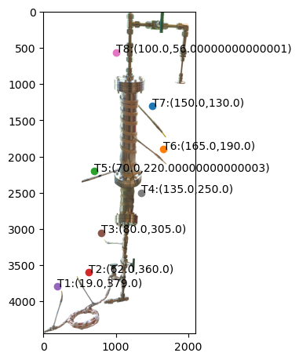

```python
import matplotlib.pyplot as plt
import matplotlib.image as mpimg

img = mpimg.imread('/Users/warisajaidee/Desktop/Purity/Temperature/GUI/diagram.png')
plt.figure(figsize=(2.5, 5.65), dpi=100)
plt.imshow(img)

def plot_labels(x,y,l):
    plt.scatter(x*1000, y*1000, label=l)
    plt.annotate(f"{l}:({x*100},{y*100})",(x*1000,y*1000))

plot_labels(1.5,1.3,"T7")
plot_labels(1.65,1.9,"T6")
plot_labels(0.70,2.2,"T5")
plot_labels(0.62,3.6, "T2")
plot_labels(0.19,3.79,"T1")
plot_labels(0.8,3.05,"T3")
plot_labels(1.00,0.56,"T8")
plot_labels(1.35,2.5,"T4")
#plt.legend()
plt.show()
```

```python
import time
from datetime import datetime as dt
formattime = dt.fromtimestamp(time.time())
print(formattime)
type(formattime)
```

```
2024-06-27 13:07:13.818192
```

```
datetime.datetime
```

```python
def calc(w,h):
    ratiow = w/250
    rew = 440*ratiow
    ratioh = h/565
    reh = 1000*ratioh
    return ratiow,rew, ratioh,reh

calc(5,495)
calc(35,400)
calc(60,400)
calc(160,300)
print(calc(55,280))
print(calc(165,230))

print(calc(160,160))
print(calc(75,56))
```

```
(0.22, 96.8, 0.49557522123893805, 495.57522123893807)
(0.66, 290.40000000000003, 0.40707964601769914, 407.07964601769913)
(0.64, 281.6, 0.2831858407079646, 283.1858407079646)
(0.3, 132.0, 0.09911504424778761, 99.11504424778761)
```

## Plotting temperatures and humidity from homemade GUI

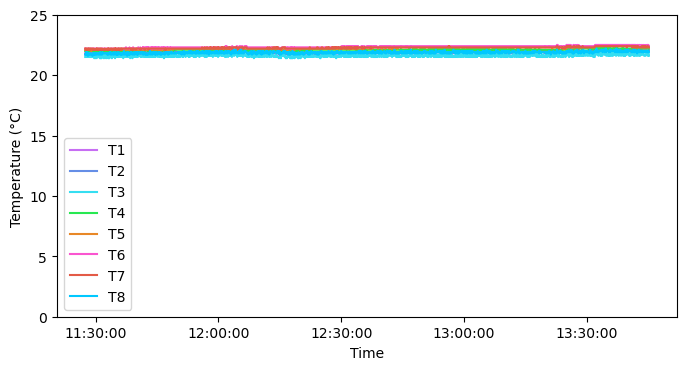

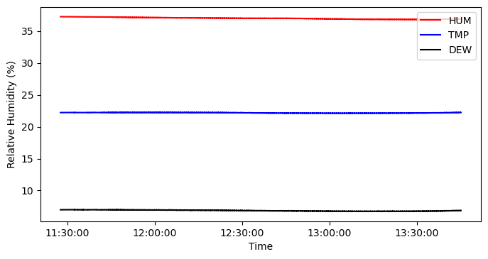

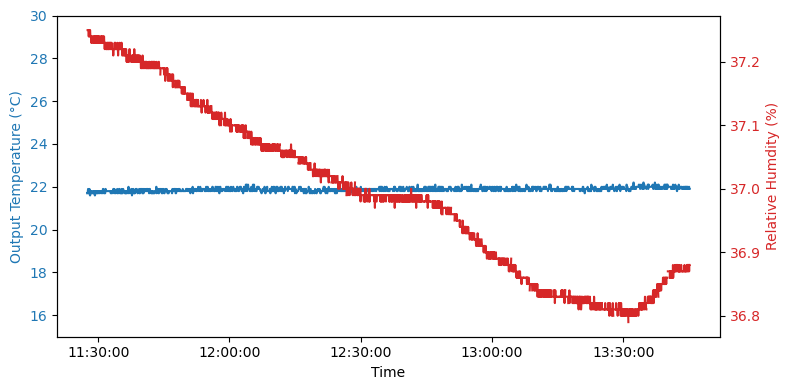

```python
import os

import numpy as np
import pandas as pd
import matplotlib.pyplot as plt

import matplotlib.dates as mdates
from datetime import datetime as dt

def plotTemp(filepath):
    plt.figure(figsize=(8,4), dpi = 100)
    colors = [(183, 101, 224), (93, 131, 212), (49, 205, 222), (36, 214, 75), (214, 125, 36), (230, 78, 192), (209, 84, 65), (0, 184, 235)]
    df = pd.read_csv(filepath)
    df['Time'] = pd.to_datetime(df['Time'], format='%Y%m%dT%H%M%S.%f')
    time = df['Time']
    for i in range(8):
        plt.plot(np.array(time), np.array(df[f"T{i+1}"]),color = [colors[i][0]/235,colors[i][1]/235,colors[i][2]/235], label = f"T{i+1}")

    plt.gca().xaxis.set_major_formatter(mdates.DateFormatter('%H:%M:%S'))
    #plt.gca().xaxis.set_major_locator(mdates.HourLocator(interval=1))
    plt.legend()
    plt.xlabel('Time')
    plt.ylabel('Temperature (°C)')
    plt.ylim(0,25)
    plt.title(filepath[60:-11])
    plt.legend()
    plt.show()

def plotHum(filepath):
    plt.figure(figsize=(8,4), dpi = 100)
    df = pd.read_csv(filepath)
    df['Time'] = pd.to_datetime(df['Time'], format='%Y%m%dT%H%M%S.%f')
    time = df['Time']
    plt.plot(np.array(time), np.array(df["HUM"]),color = 'red', label = "HUM")
    plt.plot(np.array(time), np.array(df["TMP"]),color = 'blue', label = "TMP")
    plt.plot(np.array(time), np.array(df["DEW"]),color = 'black', label = "DEW")

    plt.gca().xaxis.set_major_formatter(mdates.DateFormatter('%H:%M:%S'))
    #plt.gca().xaxis.set_major_locator(mdates.HourLocator(interval=1))
    plt.legend()
    plt.xlabel('Time')
    plt.ylabel('Relative Humidity (%)')
    plt.title(filepath[60:-11])
    plt.legend()
    plt.show()
def plotComp(tempfile, humfile):
    df_temp = pd.read_csv(tempfile)
    df_hum = pd.read_csv(humfile)

    t1 = np.array(pd.to_datetime(df_temp['Time'], format='%Y%m%dT%H%M%S.%f'))
    t2 = np.array(pd.to_datetime(df_hum['Time'], format='%Y%m%dT%H%M%S.%f'))
    data1 = np.array(df_temp['T8'])
    data2 = np.array(df_hum["HUM"])

    fig, ax1 = plt.subplots(figsize=(8,4), dpi = 100)
    color1 = 'tab:blue'
    ax1.set_xlabel('Time')
    ax1.set_ylabel('Output Temperature (°C)', color=color1)
    ax1.plot(t1, data1, color=color1)
    ax1.tick_params(axis='y', labelcolor=color1)
    ax1.set_ylim(15,30)

    ax1.xaxis.set_major_formatter(mdates.DateFormatter('%H:%M:%S'))

    ax2 = ax1.twinx()

    color2 = 'tab:red'
    ax2.set_ylabel('Relative Humdity (%)', color=color2)
    ax2.plot(t2, data2, color=color2)
    ax2.tick_params(axis='y', labelcolor=color2)

    ax2.xaxis.set_major_formatter(mdates.DateFormatter('%H:%M:%S'))

    fig.tight_layout()
    plt.show()

Folderpath = "/Users/warisajaidee/Desktop/Battatlab/"
Humfile = "hum_log_20240710T112726.csv"
Tempfile = "temp_log_20240710T112726.csv"
plotTemp(Folderpath+Tempfile)
plotHum(Folderpath+Humfile)
plotComp(Folderpath+Tempfile, Folderpath+Humfile)
```

## 20240708: RTD test

- 14.15: added some of LN2 then added the rest so that T4 is fully submerged and reached -195C, T3 is still above LN2 and reached -150
- ran out of LN --> went to refill
- 14.29: refilled more LN2 until T3 is fully submerged and reached -195C
- 14.39: started lifting T3 sensor up from LN2, kept T4 submerged
- 15.13: lifted everything up

```python
import serial
import datetime as dt
import csv
from datetime import datetime
now_time = dt.datetime.now()
timestamp = str(now_time.strftime('%Y%m%dT%H%M%S.%f')[:-3])

filename = f"{timestamp}_templog.csv"
with open(filename, 'a') as csvfile:
    csvwriter = csv.writer(csvfile)
    csvwriter.writerow(['Timestamp','RTD1', 'RTD2','RTD3', 'RTD4', 'R1', 'R2','R3','R4','T1','T2','T3','T4'])
    ser = serial.Serial('COM4', 9600, timeout = 1)
    print(ser)
    while True:
        if ser.in_waiting:
            now_time = dt.datetime.now()
            timestamp = str(now_time.strftime('%Y%m%dT%H%M%S.%f')[:-3])
            line = str(ser.readline().decode('utf-8').strip())
            parts = line.split(',')
            RTD1 = parts[0]
            RTD2 = parts[1]
            RTD3 = parts[2]
            RTD4 = parts[3]

            R1 = parts[4]
            R2 = parts[5]
            R3 = parts[6]
            R4 = parts[7]

            T1 = parts[8]
            T2 = parts[9]
            T3 = parts[10]
            T4 = parts[11]

            csvwriter.writerow([timestamp, RTD1, RTD2, RTD3, RTD4, R1, R2, R3, R4, T1, T2, T3, T4])
            print(f"{timestamp}\nRTDs: {RTD1}, {RTD2}, {RTD3}, {RTD4} \nResistants: {R1}, {R2}, {R3}, {R4}\nTemperatures:\nT1 = {T1}\nT2 = {T2}\nT3 = {T3}\nT4 = {T4} \n")

        csvfile.flush()


ser.close()
```

```python
import os
import numpy as np
import pandas as pd
import matplotlib.pyplot as plt

import matplotlib.dates as mdates
from datetime import datetime as dt

def plotRTDTemp(filepath):
    plt.figure(figsize=(10,6), dpi = 300)
    colors = [(183, 101, 224), (93, 131, 212), (49, 205, 222), (36, 214, 75)]
    df = pd.read_csv(filepath)
    df['Time'] = pd.to_datetime(df['Timestamp'], format='%Y%m%dT%H%M%S.%f')
    time = df['Time']

    for i in range(4):
        plt.plot(np.array(time), np.array(df[f"T{i+1}"]),color = [colors[i][0]/235,colors[i][1]/235,colors[i][2]/235], label = f"T{i+1}")
    plt.gca().xaxis.set_major_formatter(mdates.DateFormatter('%H:%M:%S'))
    #plt.gca().xaxis.set_major_locator(mdates.HourLocator(interval=1))
    plt.legend()
    plt.xlabel('Time')
    plt.ylabel('Temperature (°C)')
    plt.title("RTD test with liquid Nitrogen 20240708, T1=Top , T4=Bottom")
    plt.legend(loc=(0.2,0.7), fontsize=9)
    plt.show()

Folderpath = "/Users/warisajaidee/Desktop/Battatlab/"
Tempfile = "TempTest.csv"
plotRTDTemp(Folderpath+Tempfile)
```

[output not shown]

## 20240712

calculate absolute humidity from relative humidity and temperature

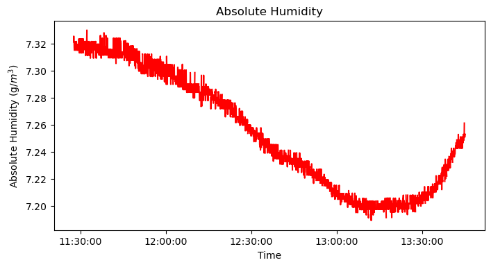

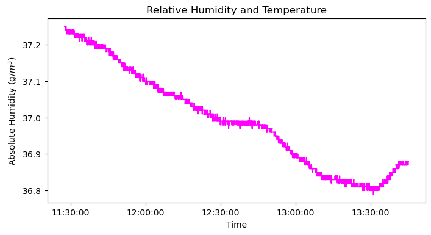

```python
def plotAbsHum(filepath):
    plt.figure(figsize=(8,4), dpi = 100)
    df = pd.read_csv(filepath)
    df['Time'] = pd.to_datetime(df['Time'], format='%Y%m%dT%H%M%S.%f')
    time = df['Time']
    T = df['TMP']
    rh = df["HUM"]
    df['absHUM'] = (6.112*np.exp((17.67*T)/(T+243.5))*rh*2.1674)/(273.15+T)
    plt.plot(np.array(time), np.array(df["absHUM"]),color = 'red')

    plt.gca().xaxis.set_major_formatter(mdates.DateFormatter('%H:%M:%S'))
    plt.xlabel('Time')
    plt.ylabel(f'Absolute Humidity (g/$m^3$)')
    plt.title("Absolute Humidity")

    plt.figure(figsize=(8,4), dpi = 100)
    plt.plot(np.array(time), np.array(df["HUM"]),color = 'magenta')
    plt.gca().xaxis.set_major_formatter(mdates.DateFormatter('%H:%M:%S'))
    plt.xlabel('Time')
    plt.ylabel(f'Absolute Humidity (g/$m^3$)')
    plt.title("Relative Humidity and Temperature")

Folderpath = "/Users/warisajaidee/Desktop/Battatlab/"
Humfile = "hum_log_20240710T112726.csv"

plotAbsHum(Folderpath+Humfile)
```

### Regen 2 data

Plotting the temperature vs time

- switched back to pure Ar at 15.32
- the humidity sensor was installed after the switch, so we missed the data during regeneration
- merged the data based on time and created new dataframe to plot

```python
#process the data since we don't have tmp readings from atlas yet, use T8 instead and merge by matching timestamp
import pandas as pd
from datetime import datetime
import matplotlib.dates as mdates

import pandas as pd
import numpy as np
import matplotlib.pyplot as plt


df_temp = pd.read_csv("regen2_temp.csv", skiprows=3)
raw_hum = pd.read_csv("regen2_hum.csv", header=None, names=['raw_data'])

processed_data = {
    'TIME': [],
    'hum': []
}

for entry in raw_hum['raw_data']:
    time, hum = entry.split(" -> HUM:")

    formatted_time = datetime.strptime(time, '%H:%M:%S.%f').strftime('%H:%M:%S')
    processed_data['TIME'].append(formatted_time)
    processed_data['hum'].append(float(hum))

df_hum = pd.DataFrame(processed_data)

merged_df = df_temp.merge(df_hum, how = 'inner', on = ['TIME'])
merged_df['absHUM'] = (6.112*np.exp((17.67*T)/(T+243.5))*rh*2.1674)/(273.15+T)
merged_df.to_csv('regen2_all.csv')
```

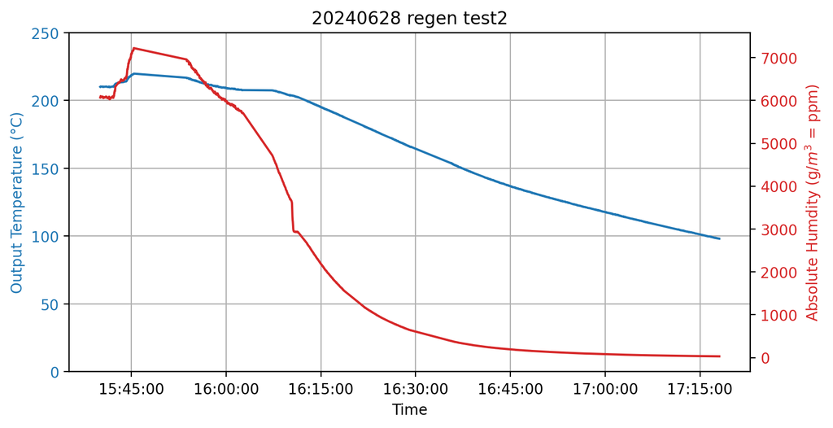

```python
import matplotlib.ticker as ticker
def plotCompAbs(merged_df):
    data1 = np.array(merged_df["\tT8 PurOUT-oC"])
    data2 = np.array(merged_df["absHUM"])
    merged_df['datetime'] = pd.to_datetime(merged_df["TIME"], format='%H:%M:%S')

    t = np.array(merged_df["datetime"])
    print()

    fig, ax1 = plt.subplots(figsize=(8,4), dpi = 200)
    color1 = 'tab:blue'
    ax1.set_xlabel('Time')
    ax1.set_ylabel('Output Temperature (°C)', color=color1)
    ax1.plot(t, data1, color=color1)
    ax1.tick_params(axis='y', labelcolor=color1)
    ax1.set_ylim(0,250)

    ax1.xaxis.set_major_formatter(mdates.DateFormatter('%H:%M:%S'))

    ax2 = ax1.twinx()

    color2 = 'tab:red'
    ax2.set_ylabel(f'Absolute Humdity (g/$m^3$ = ppm)', color=color2)
    ax2.plot(t, data2, color=color2)

    #ax2.set_ylim(6.8,7.5)
    ax2.tick_params(axis='y', labelcolor=color2)
    ax2.xaxis.set_major_formatter(mdates.DateFormatter('%H:%M:%S'))

    fig.tight_layout()
    plt.title("20240628 regen test2")
    ax1.yaxis.grid()
    ax1.xaxis.grid()
    plt.show()

plotCompAbs(merged_df)
```

For the new data format, use this code

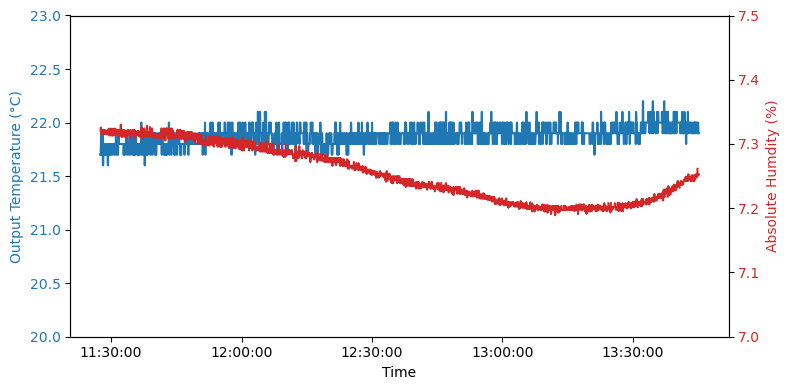

```python
#for new data format

def plotCompAbs(tempfile, humfile):
    df_temp = pd.read_csv(tempfile)
    df_hum = pd.read_csv(humfile)

    t1 = np.array(pd.to_datetime(df_temp['Time'], format='%Y%m%dT%H%M%S.%f'))
    t2 = np.array(pd.to_datetime(df_hum['Time'], format='%Y%m%dT%H%M%S.%f'))
    data1 = np.array(df_temp['T8'])


    #use the humidity sensor's temperature readings to calculate absolute humidity
    T = df_hum['TMP']
    rh = df_hum['HUM']
    df_hum['absHUM'] = (6.112*np.exp((17.67*T)/(T+243.5))*rh*2.1674)/(273.15+T)

    data2 = np.array(df_hum["absHUM"])


    fig, ax1 = plt.subplots(figsize=(8,4), dpi = 100)
    color1 = 'tab:blue'
    ax1.set_xlabel('Time')
    ax1.set_ylabel('Output Temperature (°C)', color=color1)
    ax1.plot(t1, data1, color=color1)
    ax1.tick_params(axis='y', labelcolor=color1)
    ax1.set_ylim(20,23)

    ax1.xaxis.set_major_formatter(mdates.DateFormatter('%H:%M:%S'))

    ax2 = ax1.twinx()

    color2 = 'tab:red'
    ax2.set_ylabel('Absolute Humdity (%)', color=color2)
    ax2.plot(t2,data2 , color=color2)

    ax2.set_ylim(7,7.5)
    ax2.tick_params(axis='y', labelcolor=color2)
    ax2.xaxis.set_major_formatter(mdates.DateFormatter('%H:%M:%S'))


    fig.tight_layout()
    plt.show()

Folderpath = "/Users/warisajaidee/Desktop/Battatlab/"
Humfile = "hum_log_20240710T112726.csv"
Tempfile = "temp_log_20240710T112726.csv"

plotCompAbs(Folderpath+Tempfile, Folderpath+Humfile)
```